Given data and a model design, the computer will find the model function and model values for you.  
As an example, consider the Current Population Survey data `CPS85`. Suppose you want to build a model with `wage` as a response variable and `age` and `sex` as explanatory variables incorporated as main terms. Also include the intercept term, as usual.

Using the model design language, this model is `wage` ~ 1 + `age` + `sex`.

You first need to read in the data frame.

```r
w = CPS85
```

Next, use the `lm` operator to find the model function:

```r
mod1 = lm( wage ~ 1 + age + sex, data=w)
```

The two arguments are:

1. the model design] `wage` ~ 1 + `age` + `sex`.
2. the data to be used] This always looks like `data=w` where the name of the data frame is used.

The `mod1 =`… part of the command simply gives the model a name so that you can use it later on. If you construct more than one model, it makes sense to give them different names. But don’t re-use the name of the data frame; a name can be used for only one thing at a time.

In making a graph of the function, the model values will always be plotted on the vertical axis. But you have a choice of what to put on the horizontal axis. Here are the commands which use the `xyplot` operator:

.

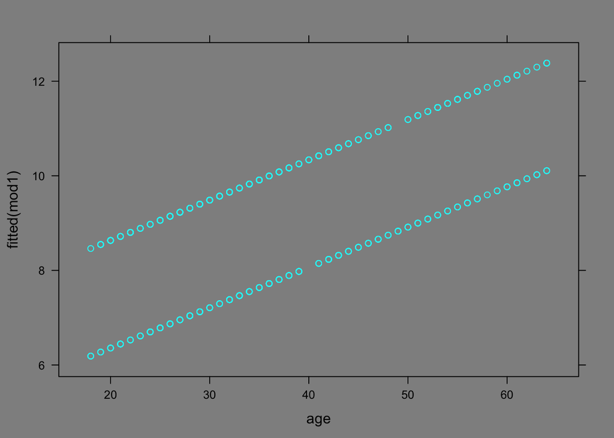

```r
xyplot( fitted(mod1) ~ age, data=w )
```

.

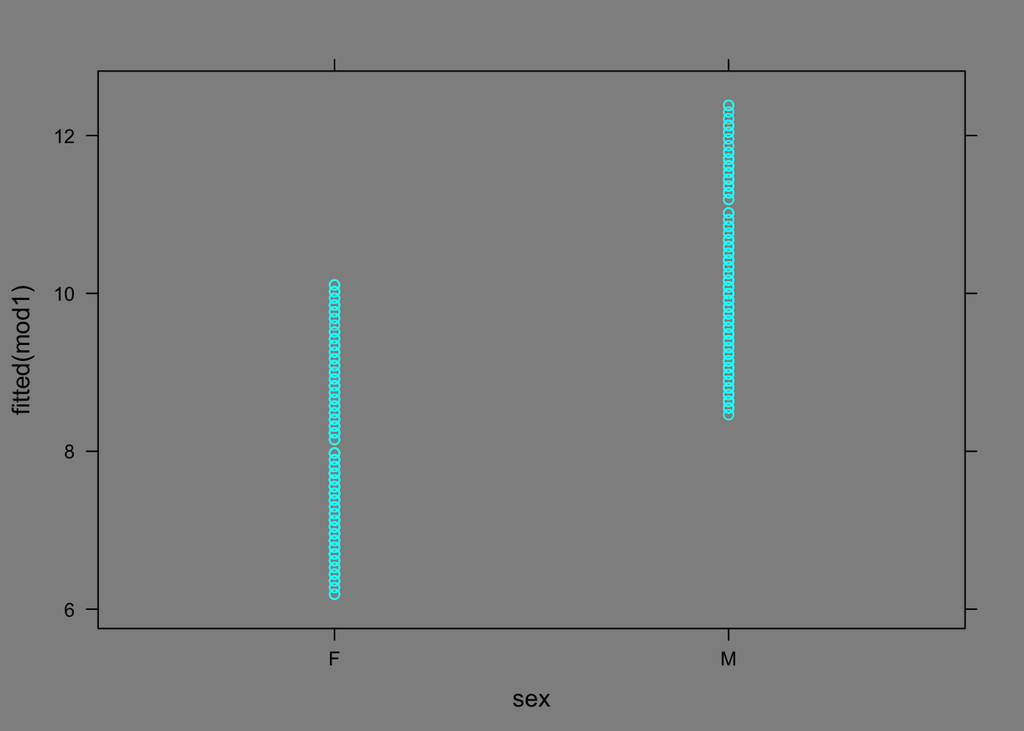

```r
print(xyplot( fitted(mod1) ~ sex, data=w ))
```

The fitted model values can be accessed with `fitted(mod1)`. The choice of which explanatory variable to plot on the horizontal axis is specified by the name following the `~` sign in the plotting command. Remember to include the name of the data frame in the last argument: `data=w`.

Some elaborations are possible.

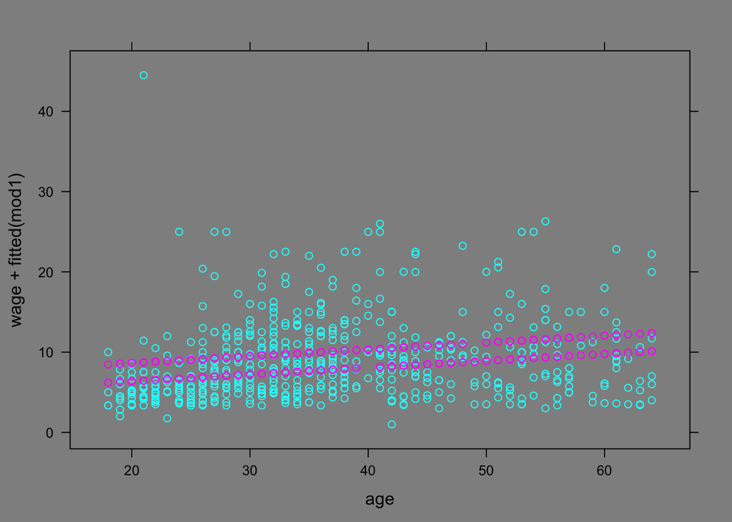

```r
print(xyplot( wage + fitted(mod1) ~ age, data=w ))
```

The `+` sign means “plot both,” not addition.

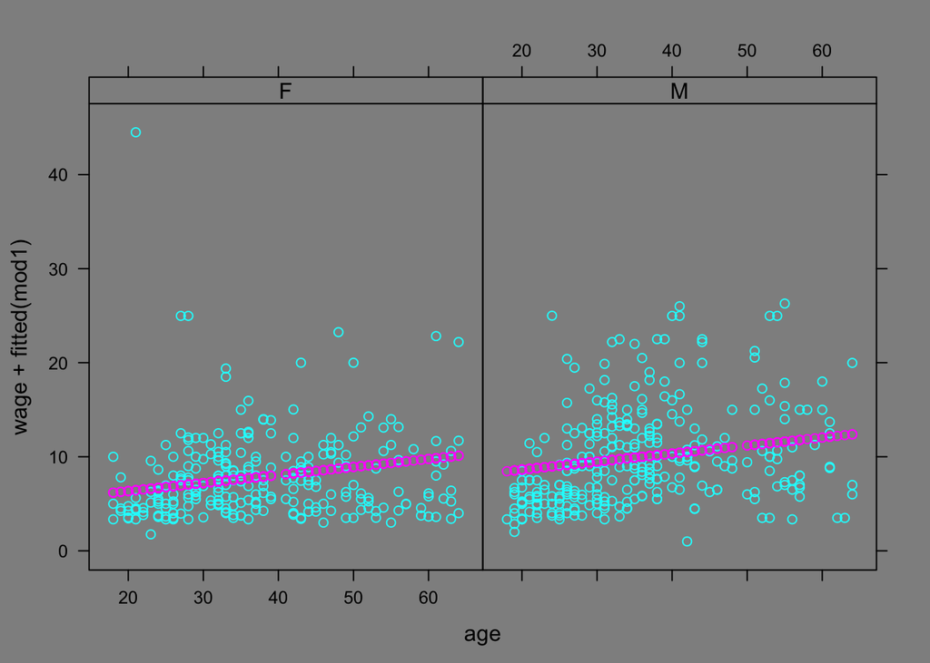

```r
xyplot( wage + fitted(mod1) ~ age | sex, data=w )
```

This uses a vertical bar followed by the name of the categorical variable. Each of the levels of the variable to the right of the vertical bar `|` will have a separate plot, so in the graphics it’s females in one plot and males in the other.

A different way to break up the display makes it easier to compare the model values for the different groups:

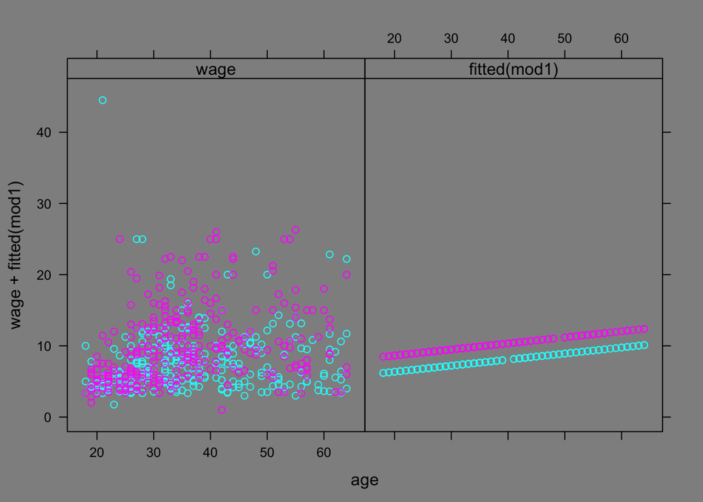

```r
xyplot(wage+fitted(mod1) ~ age,groups=sex,data=w)
```